# Dataset 2 RNA-Seq of pathogen inoculated arabidopsis with batch effects

## This example is a remake of the example (4.2) presented in the edgeR documentation

```r
# Clear variables
rm(list=ls())
#Get path
path<-getwd(); path
```

```
[1] "C:/Users/Acer/OneDrive - Universidade de Aveiro/GitHub Projects/edgeR_gene_counts/RStudio_Dataset2_Example"
```

```r
# Set path
setwd(path)
```

Samples were collected in three batches, and adjustment for batch effects proves to be important. The aim of the analysis therefore is to detect genes differentially expressed (DE) in response to ΔhrcC challenge, while correcting for any differences between the batches.

Three biological replicates of the experiment were conducted at separate times and using independently grown plants and bacteria.

## Important libraries

```r
library(BiocGenerics)
library(BiocManager)
library(edgeR)
library(DESeq2)
library(ggplot2)
library(readr)
library(dplyr)
library(readxl)
library(foreign)
library(GO.db)
```

```r
arab <- read_rds("arab.rds")
head(arab)
```

```
          mock1 mock2 mock3 hrcc1 hrcc2 hrcc3
AT1G01010    35    77    40    46    64    60
AT1G01020    43    45    32    43    39    49
AT1G01030    16    24    26    27    35    20
AT1G01040    72    43    64    66    25    90
AT1G01050    49    78    90    67    45    60
AT1G01060     0    15     2     0    21     8
```

There are two experimental factors, treatment (hrcc vs mock) and the time that each replicate was conducted (“1”, “2” and “3”):

Treatment: 2 levels Time: 3 levels

## Substring data

Substring: We can perform multiple things like extracting of values, replacement of values and more. For this we use functions like substr() and substring().

x = the input data / file Start / First= starting index of the substring Stop / Last= Ending index of the substring

substring(colnames(arab),1,4) this will get the first 4 characters of the column names, that is, h r c c and m o c k

while substring(colnames(arab),5,5) will get the fifth letter/character of the column names, that is, 1 2 3 1 2 3

```r
Treat <- factor(substring(colnames(arab),1,4))
Treat <- relevel(Treat, ref="mock")
# Define "mock" as the reference level

Time <- factor(substring(colnames(arab),5,5))
levels(Time) #Find the Time's levels order
```

```
[1] "1" "2" "3"
```

Given that we alredy defined our variables as factors, we can then create a DGEList object:

```r
y <- DGEList(counts=arab, group=Treat)
```

## Filtering and normalization

There is no purpose in analysing genes that are not expressed in either experimental condition, so genes are first filtered on expression levels.

filterbYeXPR(): This function implements the filtering strategy that was described informally by Chen et al (2016). Roughly speaking, the strategy keeps genes that have at least min.count reads in a worthwhile number samples.

the filtering keeps genes that have CPM >= CPM.cutoff in MinSampleSize samples, where CPM.cutoff = min.count/median(lib.size)*1e6 and MinSampleSize is the smallest group sample size or, more generally, the minimum inverse leverage computed from the design matrix.

```r
keep <- filterByExpr(y)
table(keep)
```

```
keep
FALSE  TRUE
12292 13930
```

```r
y <- y[keep, , keep.lib.sizes=FALSE]
```

The TMM normalization is applied to account for the compositional biases:

```r
y <- normLibSizes(y)
y$samples
```

|  | group | lib.size | norm.factors |
| --- | --- | --- | --- |
| mock1 | mock | 1882391 | 0.9771684 |
| mock2 | mock | 1870625 | 1.0228448 |
| mock3 | mock | 3227243 | 0.9142136 |
| hrcc1 | hrcc | 2101449 | 1.0584492 |
| hrcc2 | hrcc | 1243266 | 1.0828426 |
| hrcc3 | hrcc | 3494821 | 0.9548559 |

## Data exploration

An MDS plot shows the relative similarities of the six samples:

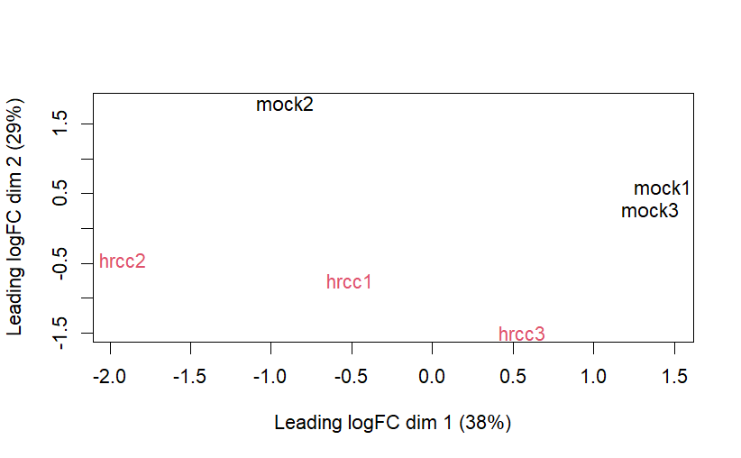

```r
plotMDS(y, col=rep(1:2, each=3))
```

## predictive log2-foldchanges (logFC)

To examine further consistency of the three replicates, we compute predictive log2-foldchanges (logFC) for the treatment separately for the three times.

```r
design <- model.matrix(~Time+Time:Treat)
logFC <- predFC(y,design,prior.count=1,dispersion=0.05)
```

The logFC at the three times are positively correlated with one another, as we would hope: (The correlation is highest between times 2 and 3)

```r
cor(logFC[,4:6])
```

```
                Time1:Treathrcc Time2:Treathrcc Time3:Treathrcc
Time1:Treathrcc       1.0000000       0.3965193       0.4974535
Time2:Treathrcc       0.3965193       1.0000000       0.5162039
Time3:Treathrcc       0.4974535       0.5162039       1.0000000
```

```r
cor(logFC[,1:3])
```

```
            (Intercept)      Time2      Time3
(Intercept)   1.0000000 -0.4341222 -0.3047461
Time2        -0.4341222  1.0000000  0.3950257
Time3        -0.3047461  0.3950257  1.0000000
```

## Design matrix

Before we fit GLMs, we need to define our design matrix based on the experimental design. We want to test for differential expressions between ΔhrcC challenged and mock-inoculated samples within batches, i.e. adjusting for differences between batches. In statistical terms, this is an additive linear model. So the design matrix is created as:

```r
design <- model.matrix(~Time+Treat)
rownames(design) <- colnames(y)
design
```

```
      (Intercept) Time2 Time3 Treathrcc
mock1           1     0     0         0
mock2           1     1     0         0
mock3           1     0     1         0
hrcc1           1     0     0         1
hrcc2           1     1     0         1
hrcc3           1     0     1         1
attr(,"assign")
[1] 0 1 1 2
attr(,"contrasts")
attr(,"contrasts")$Time
[1] "contr.treatment"

attr(,"contrasts")$Treat
[1] "contr.treatment"
```

## Dispersion estimation

Estimate the genewise dispersion estimates over all genes, allowing for a possible abundance trend. The estimation is also robustified against potential outlier genes.

```r
y <- estimateDisp(y, design, robust=TRUE)
y$common.dispersion
```

```
[1] 0.06383161
```

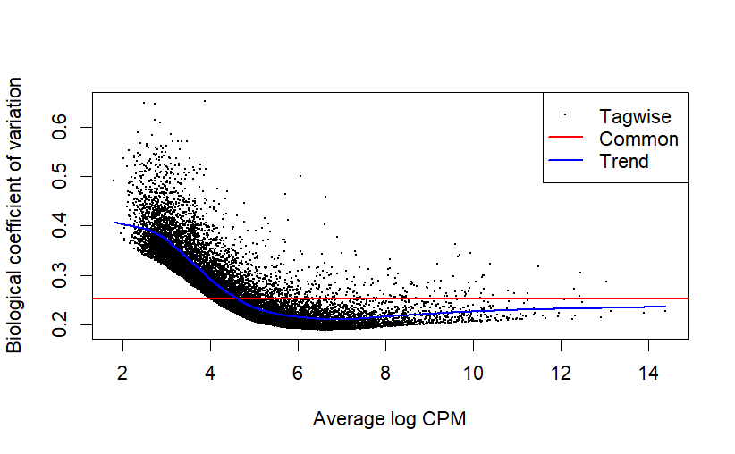

```r
plotBCV(y)
```

PLOT INTERPRETATION:

The square root of dispersion is the coefficient of biological variation (BCV). The common BCV is on the high side, considering that this is a designed experiment using genetically identical plants. The trended dispersion shows a decreasing trend with expression level. At low logCPM, the dispersions are very large indeed.

Note that only the trended dispersion is used under the quasi-likelihood (QL) pipeline. The tagwise and common estimates are shown here but will not be used further.

## QL dispersions

The QL dispersions can be estimated using the glmQLFit function, and then be visualized with the plotQLDisp function.

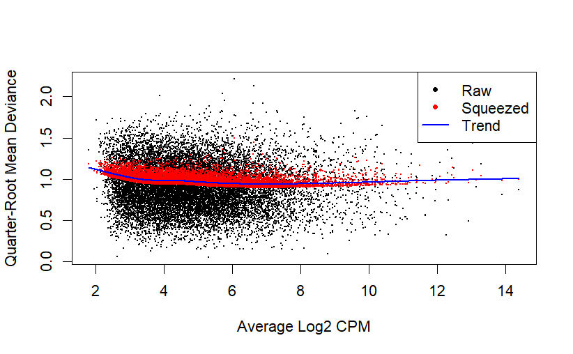

```r
fit <- glmQLFit(y, design, robust=TRUE)
plotQLDisp(fit)
```

## Differential expression

Now we test for significant differential expression in each gene using the QL F-test.

1. First we check whether there was a genuine need to adjust for the experimental times. We do this by testing for differential expression between the three times. There is considerable differential expression, justifying our decision to adjust for the batch effect:

```r
qlf <- glmQLFTest(fit, coef=2:3)
topTags(qlf)
```

```
Coefficient:  Time2 Time3
```

|  | logFC.Time2 | logFC.Time3 | logCPM | F | PValue | FDR |
| --- | --- | --- | --- | --- | --- | --- |
| AT5G31702 | 5.869803 | -2.5926684 | 5.984218 | 114.38904 | 1.084904e-08 | 0.0001033167 |
| AT3G33004 | 4.853184 | -1.7876105 | 5.670952 | 103.18098 | 1.980810e-08 | 0.0001033167 |
| AT2G11230 | 3.539660 | -1.5565485 | 5.638672 | 101.13940 | 2.225054e-08 | 0.0001033167 |
| AT2G07782 | 3.527185 | -1.6407157 | 5.315466 | 96.10242 | 2.993354e-08 | 0.0001042435 |
| AT2G23910 | 3.638907 | -0.4079832 | 5.167909 | 87.91917 | 5.007440e-08 | 0.0001180240 |
| AT2G18193 | 3.099383 | -2.4198737 | 5.108253 | 87.68928 | 5.083589e-08 | 0.0001180240 |
| AT5G54830 | 3.119206 | -0.3913081 | 6.108312 | 82.54263 | 7.199064e-08 | 0.0001432614 |
| AT2G27770 | 2.518192 | -1.5932746 | 5.460102 | 78.58116 | 9.542902e-08 | 0.0001661658 |
| AT1G05680 | 2.124867 | -1.3167210 | 6.016885 | 66.91858 | 2.378838e-07 | 0.0003681913 |
| AT4G05635 | 3.205201 | -2.4789997 | 4.796665 | 62.18824 | 3.594569e-07 | 0.0005007234 |

```r
FDR <- p.adjust(qlf$table$PValue, method="BH")
sum(FDR < 0.05)
```

```
[1] 1370
```

2. Now conduct QL F-tests for the pathogen effect and show the top genes. By default, the test is for the last coefficient in the design matrix, which in this case is the treatment effect:

```r
qlf <- glmQLFTest(fit)
topTags(qlf)
```

```
Coefficient:  Treathrcc
```

|  | logFC | logCPM | F | PValue | FDR |
| --- | --- | --- | --- | --- | --- |
| AT2G19190 | 4.479854 | 7.377057 | 308.4919 | 4.215798e-10 | 5.196858e-06 |
| AT2G39530 | 4.323271 | 6.713433 | 280.2148 | 7.461390e-10 | 5.196858e-06 |
| AT2G39380 | 4.925034 | 5.773726 | 248.6303 | 1.513305e-09 | 5.973273e-06 |
| AT3G46280 | 4.767377 | 8.095451 | 243.4038 | 1.715226e-09 | 5.973273e-06 |
| AT1G51800 | 3.950773 | 7.713585 | 232.3532 | 2.254758e-09 | 6.281757e-06 |
| AT1G51850 | 5.304065 | 5.419969 | 208.1870 | 4.293451e-09 | 8.314916e-06 |
| AT2G44370 | 5.397004 | 5.203398 | 200.0197 | 5.424356e-09 | 8.314916e-06 |
| AT3G55150 | 5.760963 | 4.908464 | 197.8497 | 5.780793e-09 | 8.314916e-06 |
| AT1G51820 | 4.319592 | 6.378183 | 197.1948 | 5.893657e-09 | 8.314916e-06 |
| AT5G48430 | 6.301469 | 6.743584 | 196.7653 | 5.969071e-09 | 8.314916e-06 |

Here’s a closer look at the individual counts-per-million for the top genes. The top genes are very consistent across the three replicates:

```r
top <- rownames(topTags(qlf))
cpm(y)[top,]
```

```
               mock1     mock2     mock3     hrcc1     hrcc2     hrcc3
AT2G19190 16.8532030 12.543385 13.218595 341.68406 262.20763 344.91538
AT2G39530  7.0674722  9.407539 13.218595 158.25367 197.58422 238.83368
AT2G39380  2.1746068  3.135846  4.745136  91.71519  86.90734 132.75197
AT3G46280 19.0278098 17.769795 18.302669 385.29373 385.51206 806.40078
AT1G51800 29.3571923 17.247154 30.504449 362.81452 358.02854 455.79174
AT1G51850  1.0873034  1.045282  3.728322  78.22767  57.93823 106.98071
AT2G44370  2.1746068  1.045282  1.694692  57.09720  69.08020  84.50577
AT3G55150  0.5436517  1.045282  1.355753  43.16009  66.85180  63.22949
AT1G51820  9.7857308  7.839616  6.100890 121.38776 161.18712 187.89048
AT5G48430  4.3492137  4.703769  0.000000 189.27498 323.85984 122.86299
```

The total number of genes significantly up-regulated or down-regulated at 5% FDR is summarized as follows:

```r
summary(decideTests(qlf))
```

```
       Treathrcc
Down         919
NotSig     12125
Up           886
```

We can plot all the logFCs against average count size, highlighting the DE (differentially expressed) genes:

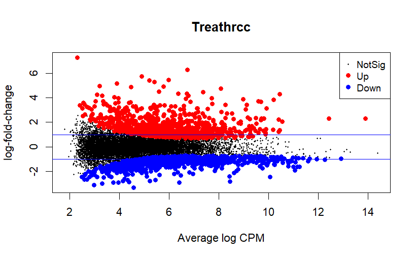

```r
plotMD(qlf)
abline(h=c(-1,1), col="blue")
```